[GitHub Python Bar Review](https://github.com/ckorikov/python-bar-review)

# Контейнеры 1

## 1. О контейнерах

**Контейнер** — объект, который содержит внутри себя другие объекты. Технически все контейнеры наследуют от `Collections.abc.Container` метод `__contains__`. С этим методом работает оператор `in`.

Контейнеры представлены разными структурами данных. На этих структурах можно построить всевозможные абстрактые типы данных.

**NB!** Не надо путать типы данных со структурами данных и абстрактными типами данных.

**Тип данных** — характеристика кусочка данных, которая определяет способ его интерпретации. Например, `b1100001` может быть как число 97 (целый тип), а может быть как символ `a` из ASCII (символ).

**Структура данных** — набор из примитивов данных и операций над ними, огранизованные для эффективного решения задачи. Например, массив) или [связный список](https://ru.wikipedia.org/wiki/%D0%A1%D0%B2%D1%8F%D0%B7%D0%BD%D1%8B%D0%B9_%D1%81%D0%BF%D0%B8%D1%81%D0%BE%D0%BA).

**Абстрактный тип данных** (АТД) — математическая модель структуры данных, ее интерфейс. Например, очередь — абстрактный тип данных, который можно реализовать на разных структурах данных.

### Проблема копирования контейнеров

В Python присваивание `=` копирует только ссылки объектов. И опреацию вида `name = obj` можно интерпретировать как присваивание объекту `obj` имени `name`. Как в таком случае скопировать объект?

Для примера, давайте попробуем скопировать список списков.

```python
# Пример списка списков
a = [1,2,3]
b = [4,5,6]
c = [a,b] # содержит ссылки на a и b
```

Если мы список `c` присвоим списку `d`, то по факту у списка `[a,b]` просто будет два имение `c` и `d`.

```python
# Навешиваем новое имя списку с (у обеъектов даолжны быть одинаковые id)
d = c
id(c), id(d)
```

```
(4508213760, 4508213760)
```

Можно скопировать список, создав явно новый с содержимым старого. При этом происходит поверхностное копирование списка. Элементы указывают на элементы старого списка.

```python
# Поверхностное копирование списка (списки разные, но внутренние объекты нет)
d = list(c)
id(c), id(d), id(c[0]), id(d[0])
```

```
(4508213760, 4508896768, 4507249728, 4507249728)
```

Различают два типа копирования:

- Поверхностное (англ. shallow)
- Глубокое (англ. deep)

В отличии от поверхностного копирования, глубокое обходит объект рекурсивно и копирует все подобъекты.

```python
# Глубокое копирование списка
from copy import deepcopy
d = deepcopy(c)
id(c), id(d), id(c[0]), id(d[0])
```

```
(4508213760, 4507242880, 4507249728, 4508854144)
```

## 2. Built-in контейнеры

Встроенные в Python-контейнеры можно разделить на две категории:

- неизменяемые (англ. immutable) `string`, `tuple`, `range`, `frozenset`, `bytes`
- изменяемые (англ. mutable) `list`, `dict`, `set`, `bytearray`

```python
# Встроенные контейнеры:
c_str = "Еду в магазин в городе Санкт-Петербурге"
c_tpl = (1, 1.2, "я")
c_rng = range(10)
c_fst = frozenset({1,2,3}) # readonly set
c_bts = bytes((3,1,4,5,1,5))
c_lst = [1,2,3]
c_dct = {1: "Sex", 2: "Drugs", 3: "Rock-and-Roll"}
c_set = {1,2,3}
c_bar = bytearray((3,1,4,5,1,5)) # writable bytes
```

### О сложности операций над популярными контейнерами

В таблице приведены некоторые популярные встроенные контейнеры и некоторые операции над ними с асимптотической сложностью.

| Контейнер | List |  | Tuple |  | Dictionary |  | Set |  |
| --- | --- | --- | --- | --- | --- | --- | --- | --- |
| Пустой контейнер | `[]` | $O(1)$ | `()` | $O(1)$ | `{}` | $O(1)$ | `Set()` или `{()}` | $O(1)$ |
| Прочитать элемент | `l[i]` | $O(1)$ | `t[i]` | $O(1)$ | `d[key]` | $O(1)$ | **undefined** | **undefined** |
| Добавить элемент | `l.append(5)` | $O(1)$ | **undefined** | **undefined** | `d[key]=5` | $O(1)$ | `s.add(5)` | $O(1)$ |
| Удалить элемент | `del l[i]` | $O(N)$ | **undefined** | **undefined** | `del d[key]` | $O(1)$ | `s.discard(5)` | $O(1)$ |

### О хэшируемости

Объекты в Python могут быть хэшиуруемые — таким объектам сопоставляется некоторое число (хэш), которое не меняется в течении существования объекта. Хэши используются для сравнения ключей в словарях и множествах. Технически, у хэшируемых объектов реализован метод `__hash__()`.

**NB!** Если контейнер и его элементы неизменяемые, то он хэшируемый.

```python
# Хэшируемый кортеж
hash((1,3,()))
```

```
7764519317587398582
```

```python
# Нехэшируемый кортеж (должна быть ошибка)
hash((1,3,[]))
```

```
---------------------------------------------------------------------------
TypeError                                 Traceback (most recent call last)
<ipython-input-7-cbf3b29f821f> in <module>
      1 # Нехэшируемый кортеж (должна быть ошибка)
----> 2 hash((1,3,[]))

TypeError: unhashable type: 'list'
```

## 3. Крутые контейнеры

Ниже приведены некоторые контейнеры из стандартной библиотеки со специальным назначением.

### namedtuple — когда нужен «сишный struct»

```python
# Пример именованного кортежа
from collections import namedtuple
Point = namedtuple('Point', ['x', 'y'])
p = Point(1,2)
```

```python
# К полям namedtuple можно обращаться через точку.
p.x
```

```
1
```

```python
# Также можно читать как обычный кортеж.
p[0]
```

```
1
```

```python
# Итерирование по именованному кортежу
for x in p:
    print(x)
```

```
1
2
```

```python
# Именованный кортеж — неизменяемый объект (должна быть ошибка)
p.x = 4
```

```
---------------------------------------------------------------------------
AttributeError                            Traceback (most recent call last)
<ipython-input-12-4ffc5fe135f6> in <module>
      1 # Именованный кортеж — неизменяемый объект (должна быть ошибка)
----> 2 p.x = 4

AttributeError: can't set attribute
```

**NB!** `namedtuple` удобно использовать для возврата данных из функций.

### OrderedDict — когда важен порядок в словаре

**Update:** В Python 3.7 уже не актуально. Стандартный `dict` гарантирует порядок.

`dict` не гарантирует, что будет хранить ключи в том порядке, в котором вы их задали. Если важно получить из `d.keys()` оригинальный порядок, то для этого есть `OrderedDict`.

```python
# Операция реверса на словаре бесмысленна — порядка нет (должна быть ошибка)
dict_std = {"a": 1, "b": 2, "c": 3}
[k for k in reversed(dict_std)]
```

```
['c', 'b', 'a']
```

```python
# Рабочий workaround в Python 3.7+
dict_std = {"a": 1, "b": 2, "c": 3}
[k for k in reversed(list(dict_std.keys()))]
```

```
['c', 'b', 'a']
```

```python
# OrderedDict предполагает наличие порядка, можно перевернуть
from collections import OrderedDict
dict_odr = OrderedDict({"a": 1, "b": 2, "c": 3})
[k for k in reversed(dict_odr)]
```

```
['c', 'b', 'a']
```

### defaultdict — когда лень инициализировать ключи

Если обратиться к ключу словаря, которого нет, то будет ошибка.

```python
# Обычный словарь ругается на поля, которых нет (должна быть ошибка)
d = {}
d["4"]
```

```
---------------------------------------------------------------------------
KeyError                                  Traceback (most recent call last)
<ipython-input-16-c9aa461dd7f1> in <module>
      1 # Обычный словарь ругается на поля, которых нет (должна быть ошибка)
      2 d = {}
----> 3 d["4"]

KeyError: '4'
```

Если надо какое-то поведение по-умолчанию, то для этого удобно использовать `defaultdict`.

```python
# Пример с defaultdict, ключу по-умолчанию присвается 0.
from collections import defaultdict

s = 'я заливаю глаза керосином'
d = defaultdict(int)

for k in s:
    d[k] += 1 # без defaultdict здесь надо было  бы инициализировать ключи явно

sorted(d.items(), key=lambda x: x[1], reverse=True)
```

```
[('а', 4),
 (' ', 3),
 ('з', 2),
 ('л', 2),
 ('и', 2),
 ('о', 2),
 ('я', 1),
 ('в', 1),
 ('ю', 1),
 ('г', 1),
 ('к', 1),
 ('е', 1),
 ('р', 1),
 ('с', 1),
 ('н', 1),
 ('м', 1)]
```

### ChainMap — когда нужно несколько словарей представить как один

`ChainMap` хранит ссылки на другие словари. Контейнер позволяет работать с внутренними словарями как с одним целым словарем.

У `ChainMap` есть два традиционных приложения:

- Возвращать значения по-умполчанию из словаря, если ключа нет.
- Поиск по нескольких словарям.

```python
# Пример с ChainMap: поиск по двум словарям
from collections import ChainMap

group1 = {"a": 1, "b": 2}
group2 = {"c": 3, "d": 4}
groups = ChainMap(group1, group2)
groups["d"], groups["b"]
```

```
(4, 2)
```

Здесь `group1` может быть словарём параметров, а `group2` — словарём значений параметров по-умолчанию. Если значения нет в `group1`, то вернётся значение из `group2`.

### MappingProxyType — когда нужен словарь только для чтения

```python
# Пример словаря, в который нельзя писать
from types import MappingProxyType

d = {"a": 1, "b": 2} # Обычный словарь
d_ro = MappingProxyType(d) # MappingProxyType (Read Only)

d_ro["a"]
```

```
1
```

```python
# Записать в MappingProxyType нельзя (должна быть ошибка)
d_ro["a"] = 1
```

```
---------------------------------------------------------------------------
TypeError                                 Traceback (most recent call last)
<ipython-input-20-819d3d450b91> in <module>
      1 # Записать в MappingProxyType нельзя (должна быть ошибка)
----> 2 d_ro["a"] = 1

TypeError: 'mappingproxy' object does not support item assignment
```

### Counter — когда надо мультимножество

**Мультимножество** — множество, элементы в котором могут повторяться.

```python
# Пример построения мультимножества по итерируемому объекту (строке)
from collections import Counter

s = 'я заливаю глаза керосином'
c = Counter(s)
c
```

[output not shown]

```python
# sum — количество элементов в множестве,
# len - количество уникальных элементов в множестве
sum(c.values()), len(c.values())
```

```
(25, 16)
```

### deque — когда нужен двусторонний доступ

И очередь и стек можно реализовать на `list`. Но `list` реализован на динамическом массиве, а `deque` на связном списке.

```python
# Пример двусторонней очереди
from collections import deque
d = deque()
d.append("я")
d.append("иду")
d.append("брать")
d.append("лут")
d.popleft(), d.pop()
```

```
('я', 'лут')
```

### heapq — когда нужна очередь с приоритетом

```python
# Пример
from heapq import heappush, heappop

q = []
heappush(q, (3, "Продакшен"))
heappush(q, (1, "Чпок"))
heappush(q, (2, "Чпок"))

heappop(q),heappop(q),heappop(q)
```

```
((1, 'Чпок'), (2, 'Чпок'), (3, 'Продакшен'))
```

### dataclasses — когда от класса надо только хранение данных

Когда нужен изменяемый `namedtuple`, то подходит `dataclasses`.

```python
# Пример с собственным dataclass
from dataclasses import dataclass

@dataclass
class Structure:
    name: str
    value: float

    @property
    def square(self) -> float:
        return self.value * self.value

s = Structure("я", 2)
s.square
```

```
4
```

По-умолчанию `dataclass` генерирует 3 дандер-метода (метод с двойным подчеркиванием):

- `init`,
- `repr`,
- `eq`.

Через опции декоратора можно сделать `dataclass` immutable (`frozen`), mutable-хэшируемым (`unsafe_hash`) и сравниваемым (`order`).

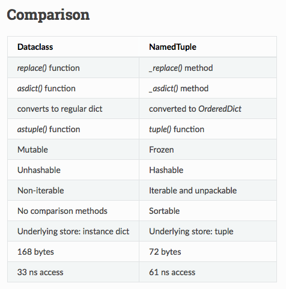

```python
%load_ext watermark
%watermark -d -u -v -iv
```

```
last updated: 2019-10-21

CPython 3.8.0
IPython 7.8.0
```